# Panel semana x cuadrante — SAIDI/SAIFI: infraestructura, NDVI y cuadrantes reales

Cindy Carolina Lugo Rozo

2026-09-07

# Introducción

Este documento consolida dos insumos del panel **semana x cuadrante** usado para pronosticar y explicar SAIDI y SAIFI:

1. **Infraestructura eléctrica por cuadrante** (`fallas_eventos.gpkg`): inventario físico georreferenciado de activos de red (aisladores, cuchillas, interruptores, reconectadores, transformadores), agregado a nivel de cuadrante. Es una variable **estática** (no varía semana a semana).
2. **NDVI semanal por cuadrante** (MODIS MOD13Q1): índice de vegetación activa, que sí varía semana a semana y por tanto se puede identificar en modelos con efectos fijos de cuadrante.

**Cambio clave respecto a versiones anteriores:** los centroides de cuadrante usados para descargar NDVI ya no se aproximan con polígonos de Voronoi ni con el promedio de puntos de infraestructura. Se calculan con `st_centroid()` sobre la geometría **real** de los cuadrantes (`cuadrantes_infra`, cargada desde el `.gpkg`), lo que hace innecesaria cualquier aproximación posterior.

# Parte 1 — Infraestructura eléctrica por cuadrante

## Paquetes

```r
library(sf)
library(dplyr)
library(tidyr)
library(knitr)
library(kableExtra)
```

```r
# Misma logica que Scripts/Edwin/analisis_correlacion.Rmd.
# Este Rmd vive en Scripts/Cindy/v4/ → el .env de la raiz esta 3 niveles arriba.
env_path <- file.path("..", "..", "..", ".env")
if (file.exists(".env")) {
  readRenviron(".env")
} else if (file.exists(env_path)) {
  readRenviron(env_path)
}

UBICACION_DATA <- Sys.getenv("UBICACION_DATA")
if (UBICACION_DATA == "") {
  stop("UBICACION_DATA no esta definida. Verifica el archivo .env.")
}

cat(sprintf("UBICACION_DATA: %s\n", UBICACION_DATA))
```

```
## UBICACION_DATA: D:/OneDrive - PUJ Cali/Projecto_Grado_Javeriana/Data_Project/
```

```r
DIR_IMAGENES <- file.path(
  UBICACION_DATA, "imagenes", "panel_saidi_saifi_cuadrantes_reales"
)
DIR_CACHE <- file.path(
  UBICACION_DATA, "cache", "panel_saidi_saifi_cuadrantes_reales"
)
dir.create(DIR_IMAGENES, recursive = TRUE, showWarnings = FALSE)
dir.create(DIR_CACHE, recursive = TRUE, showWarnings = FALSE)
knitr::opts_chunk$set(
  fig.path = paste0(DIR_IMAGENES, "/"),
  dev = "png",
  cache.path = paste0(DIR_CACHE, "/")
)
```

## Carga de capas desde el .gpkg

```r
ruta_gpkg_infra <- file.path(UBICACION_DATA, "fallas_eventos.gpkg")

st_layers(ruta_gpkg_infra)   # inventario de capas disponibles
```

```
## Driver: GPKG
## Available layers:
##             layer_name geometry_type features fields crs_name
## 1       fallas_eventos         Point    47652      7   WGS 84
## 2 cuadrantes_poligonos Multi Polygon      344      4   WGS 84
```

```r
fallas_eventos <- st_read(
  ruta_gpkg_infra,
  layer = "fallas_eventos",
  quiet = TRUE
)

cuadrantes_poligonos <- st_read(
  ruta_gpkg_infra,
  layer = "cuadrantes_poligonos",
  quiet = TRUE
)

cat(sprintf(
  "fallas_eventos: %d elementos | cuadrantes_poligonos: %d polígonos\n",
  nrow(fallas_eventos), nrow(cuadrantes_poligonos)
))
```

```
## fallas_eventos: 47652 elementos | cuadrantes_poligonos: 344 polígonos
```

## Distribución de los elementos de infraestructura

Revisión de la composición del inventario antes de construir las variables agregadas, para saber qué tipos de activos están disponibles.

```r
tipos_infra <- fallas_eventos %>%
  st_drop_geometry() %>%
  count(TIPO, sort = TRUE)

kable(
  tipos_infra,
  caption = "Distribución de los elementos de infraestructura eléctrica"
)
```

Distribución de los elementos de infraestructura eléctrica

| TIPO | n |
| --- | --- |
| Transformador | 25405 |
| Aisladero | 19080 |
| Cuchilla | 2527 |
| Reconectador | 367 |
| Interruptor | 273 |

## Número de elementos de cada tipo por cuadrante

```r
infra_tipo <- fallas_eventos %>%
  st_drop_geometry() %>%
  count(CUADRANTE, TIPO, name = "n") %>%
  pivot_wider(
    names_from  = TIPO,
    values_from = n,
    values_fill = 0
  )
```

## Estandarización de nombres

**Corrección de robustez:** si algún tipo de elemento no aparece en la muestra, `pivot_wider()` no crea esa columna y el `rename()` fallaría. Se agrega una verificación previa que crea en cero cualquier columna faltante.

```r
tipos_esperados <- c(
  "Aisladero", "Cuchilla", "Interruptor", "Reconectador", "Transformador"
)

faltantes <- setdiff(tipos_esperados, names(infra_tipo))
if (length(faltantes) > 0) infra_tipo[faltantes] <- 0

infra_cuadrante <- infra_tipo %>%
  rename(
    n_aisladeros      = Aisladero,
    n_cuchillas       = Cuchilla,
    n_interruptores   = Interruptor,
    n_reconectadores  = Reconectador,
    n_transformadores = Transformador
  )
```

## Número total de elementos (`n_elementos`)

Tamaño absoluto del inventario de infraestructura por cuadrante. Representa exposición estructural, **no** número de fallas.

```r
infra_cuadrante <- infra_cuadrante %>%
  mutate(
    n_elementos =
      n_aisladeros + n_cuchillas + n_interruptores +
      n_reconectadores + n_transformadores
  )
```

## Diversidad de infraestructura (`n_tipos_infraestructura`)

Rango 1–5. Variable exploratoria de heterogeneidad; no se recomienda como variable principal por su rango limitado.

```r
infra_cuadrante <- infra_cuadrante %>%
  mutate(
    n_tipos_infraestructura =
      rowSums(
        across(
          c(n_aisladeros, n_cuchillas, n_interruptores,
            n_reconectadores, n_transformadores)
        ) > 0
      )
  )
```

## Participación de cada tipo (`prop_*`)

**Corrección:** se evita división por cero (`NaN`) cuando `n_elementos == 0`, forzando la proporción a 0 en ese caso.

```r
infra_cuadrante <- infra_cuadrante %>%
  mutate(
    prop_aisladeros      = if_else(n_elementos == 0, 0, n_aisladeros      / n_elementos),
    prop_cuchillas       = if_else(n_elementos == 0, 0, n_cuchillas       / n_elementos),
    prop_interruptores   = if_else(n_elementos == 0, 0, n_interruptores   / n_elementos),
    prop_reconectadores  = if_else(n_elementos == 0, 0, n_reconectadores  / n_elementos),
    prop_transformadores = if_else(n_elementos == 0, 0, n_transformadores / n_elementos)
  )
```

## Tabla final de infraestructura por cuadrante

```r
infra_cuadrante <- infra_cuadrante %>%
  select(
    CUADRANTE,
    n_elementos, n_tipos_infraestructura,
    n_transformadores, n_aisladeros, n_cuchillas,
    n_interruptores, n_reconectadores,
    prop_transformadores, prop_aisladeros, prop_cuchillas,
    prop_interruptores, prop_reconectadores
  )

kable(head(infra_cuadrante, 10),
      caption = "Vista previa: infraestructura por cuadrante") %>%
  kable_styling(bootstrap_options = c("striped", "condensed"), font_size = 10)
```

Vista previa: infraestructura por cuadrante

| CUADRANTE | n_elementos | n_tipos_infraestructura | n_transformadores | n_aisladeros | n_cuchillas | n_interruptores | n_reconectadores | prop_transformadores | prop_aisladeros | prop_cuchillas | prop_interruptores | prop_reconectadores |
| --- | --- | --- | --- | --- | --- | --- | --- | --- | --- | --- | --- | --- |
| 1 | 1 | 1 | 1 | 0 | 0 | 0 | 0 | 1.0000000 | 0.0000000 | 0.0000000 | 0 | 0.000000 |
| 2 | 20 | 2 | 12 | 8 | 0 | 0 | 0 | 0.6000000 | 0.4000000 | 0.0000000 | 0 | 0.000000 |
| 3 | 15 | 3 | 4 | 10 | 1 | 0 | 0 | 0.2666667 | 0.6666667 | 0.0666667 | 0 | 0.000000 |
| 4 | 26 | 2 | 18 | 8 | 0 | 0 | 0 | 0.6923077 | 0.3076923 | 0.0000000 | 0 | 0.000000 |
| 5 | 1 | 1 | 1 | 0 | 0 | 0 | 0 | 1.0000000 | 0.0000000 | 0.0000000 | 0 | 0.000000 |
| 6 | 2 | 1 | 2 | 0 | 0 | 0 | 0 | 1.0000000 | 0.0000000 | 0.0000000 | 0 | 0.000000 |
| 7 | 77 | 4 | 36 | 36 | 4 | 0 | 1 | 0.4675325 | 0.4675325 | 0.0519481 | 0 | 0.012987 |
| 8 | 47 | 3 | 25 | 21 | 1 | 0 | 0 | 0.5319149 | 0.4468085 | 0.0212766 | 0 | 0.000000 |
| 9 | 7 | 2 | 5 | 2 | 0 | 0 | 0 | 0.7142857 | 0.2857143 | 0.0000000 | 0 | 0.000000 |
| 10 | 84 | 2 | 43 | 41 | 0 | 0 | 0 | 0.5119048 | 0.4880952 | 0.0000000 | 0 | 0.000000 |

## Verificaciones de consistencia

```r
infra_cuadrante <- infra_cuadrante %>%
  mutate(
    verificacion_total =
      n_elementos - (n_aisladeros + n_cuchillas + n_interruptores +
                      n_reconectadores + n_transformadores),
    verificacion_proporciones =
      prop_aisladeros + prop_cuchillas + prop_interruptores +
      prop_reconectadores + prop_transformadores
  )

# Debe ser 0 en todos los cuadrantes
table(infra_cuadrante$verificacion_total)
```

```
##
##   0
## 344
```

```r
# Debe ser 1 donde n_elementos > 0, y 0 donde n_elementos == 0
summary(infra_cuadrante$verificacion_proporciones[infra_cuadrante$n_elementos > 0])
```

```
##    Min. 1st Qu.  Median    Mean 3rd Qu.    Max.
##       1       1       1       1       1       1
```

```r
table(infra_cuadrante$verificacion_proporciones[infra_cuadrante$n_elementos == 0])
```

```
## < table of extent 0 >
```

## Unión de infraestructura a la geometría real de los cuadrantes

`cuadrantes_infra` es el objeto que se usa de aquí en adelante para todo lo espacial (centroides reales, mapas, exportaciones).

```r
cuadrantes_infra <- cuadrantes_poligonos %>%
  left_join(infra_cuadrante, by = "CUADRANTE") %>%
  st_transform(4326)

fallas_eventos <- st_transform(fallas_eventos, 4326)

cat(sprintf("cuadrantes_infra: %d polígonos con variables de infraestructura unidas\n",
            nrow(cuadrantes_infra)))
```

```
## cuadrantes_infra: 344 polígonos con variables de infraestructura unidas
```

# Parte 2 — Centroides reales para NDVI (sin Voronoi)

Se calcula el centroide geométrico real de cada cuadrante a partir de `cuadrantes_infra`, reemplazando cualquier aproximación previa basada en polígonos de Voronoi o en el promedio de puntos de infraestructura.

```r
centroides_cuadrante_real <- cuadrantes_infra %>%
  st_centroid() %>%
  mutate(
    lon = st_coordinates(.)[, 1],
    lat = st_coordinates(.)[, 2]
  ) %>%
  st_drop_geometry() %>%
  select(CUADRANTE, lat, lon)

cat(sprintf("Centroides reales: %d cuadrantes\n", nrow(centroides_cuadrante_real)))
```

```
## Centroides reales: 344 cuadrantes
```

# Parte 3 — NDVI semanal por cuadrante (MODIS MOD13Q1)

## Por qué NDVI y no árboles estáticos OSM

En un modelo de panel con efectos fijos de cuadrante ($\alpha_i$), una variable que no varía en el tiempo queda perfectamente colineal con el efecto fijo y su coeficiente no puede identificarse:

$$y_{it} = \alpha_i + \beta \cdot
\underbrace{x_i}_{\text{sin variación temporal}} + \varepsilon_{it}
\quad \Rightarrow \quad \beta \text{ no identificado}$$

NDVI mide actividad fotosintética real de la vegetación y **varía semana a semana**, por lo que sí puede identificarse en modelos con efectos fijos.

**Fuente:** producto MODIS MOD13Q1 (Terra, NASA), composite de 16 días, resolución 250 m, vía paquete `MODISTools`.

```r
# Mirror de CRAN explícito: evita el error "trying to use CRAN without
# setting a mirror" al instalar paquetes en modo knit (no interactivo).
options(repos = c(CRAN = "https://cloud.r-project.org"))

paquetes_ndvi <- c("MODISTools", "dplyr", "lubridate", "tidyr",
                   "ggplot2", "knitr", "kableExtra", "purrr",
                   "readr", "scales", "zoo")

invisible(lapply(paquetes_ndvi, function(p) {
  if (!requireNamespace(p, quietly = TRUE)) install.packages(p)
  library(p, character.only = TRUE)
}))
```

```
##
##  C:\Users\ESILVAS\AppData\Local\Temp\RtmpmCjPym\downloaded_packages
```

## Cargar tabla maestra del panel

`data_final` debe contener, como mínimo, `id_cuadrante` y `semana` (la unidad muestral semana x cuadrante). `id_cuadrante` se fuerza a texto desde este mismo chunk, para que todos los joins posteriores del documento sean consistentes sin necesidad de recordar convertirlo cada vez.

```r
ruta_data_final <- file.path(UBICACION_DATA, "data_agrupada_mod.csv")

if (!file.exists(ruta_data_final)) {
  stop(
    "No se encontró data_agrupada_mod.csv en:\n  ", ruta_data_final,
    "\n\nBusca la ruta real con:\n",
    "  list.files('C:/Users/User', pattern = 'data_agrupada_mod.csv', recursive = TRUE, full.names = TRUE)"
  )
}

data_final <- read_csv(ruta_data_final, show_col_types = FALSE) %>%
  mutate(id_cuadrante = as.character(id_cuadrante))

cat(sprintf("data_final: %d filas | %d cuadrantes | rango %s a %s\n",
            nrow(data_final),
            n_distinct(data_final$id_cuadrante),
            min(data_final$semana, na.rm = TRUE),
            max(data_final$semana, na.rm = TRUE)))
```

```
## data_final: 36120 filas | 344 cuadrantes | rango 2024-01-01 a 2025-12-29
```

## Centroides para MODIS: se usan los reales (no Voronoi)

`id_cuadrante` se homologa con `CUADRANTE` (mismo identificador, dos nombres distintos entre el pipeline de infraestructura y el de `data_final`). Se estandariza a `id_cuadrante` en formato texto para que el join sea exacto y no falle por tipos numéricos vs. carácter.

```r
centroides <- centroides_cuadrante_real %>%
  rename(id_cuadrante = CUADRANTE) %>%
  mutate(id_cuadrante = as.character(id_cuadrante)) %>%
  distinct(id_cuadrante, .keep_all = TRUE)

data_final <- data_final %>%
  mutate(id_cuadrante = as.character(id_cuadrante))

cat(sprintf("Cuadrantes únicos (geometría real): %d\n", nrow(centroides)))
```

```
## Cuadrantes únicos (geometría real): 344
```

```r
# ------------------------------------------------------------------
# Verificación de correspondencia de identificadores
# ------------------------------------------------------------------
# Antes de descargar NDVI, se confirma que los cuadrantes del panel
# (data_final) y los de la geometría real (centroides) coincidan.
# Un mismatch aquí (ceros a la izquierda, formatos distintos, etc.)
# se propagaría silenciosamente como NA en todas las uniones futuras.
# ------------------------------------------------------------------

ids_panel      <- unique(data_final$id_cuadrante)
ids_geometria  <- unique(centroides$id_cuadrante)

solo_en_panel     <- setdiff(ids_panel, ids_geometria)
solo_en_geometria <- setdiff(ids_geometria, ids_panel)

cat(sprintf(
  "Cuadrantes solo en data_final (sin geometría real): %d\n",
  length(solo_en_panel)
))
```

```
## Cuadrantes solo en data_final (sin geometría real): 0
```

```r
cat(sprintf(
  "Cuadrantes solo en la geometría real (sin datos en el panel): %d\n",
  length(solo_en_geometria)
))
```

```
## Cuadrantes solo en la geometría real (sin datos en el panel): 0
```

```r
if (length(solo_en_panel) > 0) {
  cat("IDs sin geometría (revisar formato/typos antes de continuar):\n")
  print(head(solo_en_panel, 20))
}

fecha_min <- min(data_final$semana, na.rm = TRUE)
fecha_max <- max(data_final$semana, na.rm = TRUE)
anio_inicio <- year(fecha_min)
anio_fin    <- year(fecha_max)

cat(sprintf("Período del dataset: %s → %s  (años MODIS: %d–%d)\n",
            fecha_min, fecha_max, anio_inicio, anio_fin))
```

```
## Período del dataset: 2024-01-01 → 2025-12-29  (años MODIS: 2024–2025)
```

## Función de descarga NDVI por cuadrante

```r
#' Descarga NDVI MODIS para un cuadrante dado su centroide real
#'
#' @param id_cuadrante  Identificador del cuadrante
#' @param lat, lon      Coordenadas del centroide real (WGS84)
#' @param anio_inicio, anio_fin  Rango temporal
#' @param km_buffer     Radio del buffer alrededor del centroide (km)
#' @param pausa_seg     Pausa de cortesía entre consultas
#' @return data.frame con id_cuadrante, fecha_composite, ndvi_medio

descargar_ndvi_cuadrante <- function(id_cuadrante, lat, lon,
                                      anio_inicio, anio_fin,
                                      km_buffer = 5,
                                      pausa_seg = 3) {
  resultado <- tryCatch({

    raw <- mt_subset(
      product   = "MOD13Q1",
      band      = "250m_16_days_NDVI",
      lat       = lat,
      lon       = lon,
      start     = paste0(anio_inicio, "-01-01"),
      end       = paste0(anio_fin,    "-12-31"),
      km_ab     = km_buffer,
      km_lr     = km_buffer,
      internal  = TRUE,
      progress  = FALSE
    )

    # NDVI escalado x10000; fill value = -3000 -> NA
    raw %>%
      mutate(
        ndvi_raw = as.numeric(value),
        ndvi     = if_else(ndvi_raw < -2000, NA_real_, ndvi_raw / 10000),
        fecha_composite = as.Date(calendar_date)
      ) %>%
      filter(!is.na(ndvi)) %>%
      group_by(fecha_composite) %>%
      summarise(
        ndvi_medio = mean(ndvi, na.rm = TRUE),
        ndvi_sd    = sd(ndvi,   na.rm = TRUE),
        n_pixeles  = n(),
        .groups = "drop"
      ) %>%
      mutate(id_cuadrante = id_cuadrante, descarga_ok = TRUE)

  }, error = function(e) {
    message("  ERROR cuadrante ", id_cuadrante, ": ", conditionMessage(e))
    data.frame(
      fecha_composite = as.Date(NA), ndvi_medio = NA_real_,
      ndvi_sd = NA_real_, n_pixeles = NA_integer_,
      id_cuadrante = id_cuadrante, descarga_ok = FALSE,
      stringsAsFactors = FALSE
    )
  })

  Sys.sleep(pausa_seg)
  return(resultado)
}
```

## Descarga por lotes con caché y reanudación

```r
CACHE_NDVI   <- file.path(UBICACION_DATA, "ndvi_por_cuadrante_real_modis.csv")
PARCIAL_NDVI <- file.path(UBICACION_DATA, "ndvi_parcial_temp.csv")
TAM_LOTE     <- 30
PAUSA_LOTE   <- 15
PAUSA_ITEM   <- 4

if (file.exists(CACHE_NDVI)) {

  ndvi_raw <- read_csv(CACHE_NDVI, show_col_types = FALSE) %>%
    mutate(
      fecha_composite = as.Date(fecha_composite),
      id_cuadrante    = as.character(id_cuadrante)
    )
  cat(sprintf("Cache NDVI: %d registros de %d cuadrantes desde '%s'\n",
              nrow(ndvi_raw), n_distinct(ndvi_raw$id_cuadrante), CACHE_NDVI))

} else {

  ya_descargados <- character(0)
  if (file.exists(PARCIAL_NDVI)) {
    parcial        <- read_csv(PARCIAL_NDVI, show_col_types = FALSE)
    ya_descargados <- unique(as.character(parcial$id_cuadrante))
    cat(sprintf("Reanudando: %d cuadrantes ya procesados\n", length(ya_descargados)))
  }

  pendientes <- centroides %>%
    filter(!as.character(id_cuadrante) %in% ya_descargados)

  cat(sprintf("Cuadrantes por descargar: %d\n", nrow(pendientes)))

  lotes <- split(seq_len(nrow(pendientes)),
                 ceiling(seq_len(nrow(pendientes)) / TAM_LOTE))

  for (i in seq_along(lotes)) {
    lote <- pendientes[lotes[[i]], ]
    cat(sprintf("\nLote NDVI %d / %d  (%d cuadrantes)...\n",
                i, length(lotes), nrow(lote)))

    res <- pmap_dfr(
      .l = lote %>% select(id_cuadrante, lat, lon),
      .f = descargar_ndvi_cuadrante,
      anio_inicio = anio_inicio, anio_fin = anio_fin,
      km_buffer = 5, pausa_seg = PAUSA_ITEM
    )

    write_csv(res, PARCIAL_NDVI, append = file.exists(PARCIAL_NDVI))

    if (i < length(lotes)) {
      cat(sprintf("  Pausa %d s...\n", PAUSA_LOTE))
      Sys.sleep(PAUSA_LOTE)
    }
  }

  ndvi_raw <- read_csv(PARCIAL_NDVI, show_col_types = FALSE) %>%
    mutate(
      fecha_composite = as.Date(fecha_composite),
      id_cuadrante    = as.character(id_cuadrante)
    )
  write_csv(ndvi_raw, CACHE_NDVI)
  file.remove(PARCIAL_NDVI)

  cat(sprintf("NDVI completo: %d registros guardados en '%s'\n",
              nrow(ndvi_raw), CACHE_NDVI))
}
```

```
## Cache NDVI: 15818 registros de 344 cuadrantes desde 'D:/OneDrive - PUJ Cali/Projecto_Grado_Javeriana/Data_Project//ndvi_por_cuadrante_real_modis.csv'
```

```r
# ------------------------------------------------------------------
# Estandarización final de tipos y deduplicación
# ------------------------------------------------------------------
# id_cuadrante puede haber quedado con mezcla de tipos si el caché se
# combinó con descargas de sesiones distintas. Se fuerza a character y
# se colapsa cualquier duplicado resultante (se conserva la fila con
# descarga_ok = TRUE si existe más de una para el mismo id+fecha).
# ------------------------------------------------------------------

ndvi_raw <- ndvi_raw %>%
  mutate(id_cuadrante = as.character(id_cuadrante)) %>%
  arrange(id_cuadrante, fecha_composite, desc(descarga_ok)) %>%
  distinct(id_cuadrante, fecha_composite, .keep_all = TRUE)

write_csv(ndvi_raw, CACHE_NDVI)

cat(sprintf("ndvi_raw estandarizado: %d registros | %d cuadrantes únicos\n",
            nrow(ndvi_raw), n_distinct(ndvi_raw$id_cuadrante)))
```

```
## ndvi_raw estandarizado: 15818 registros | 344 cuadrantes únicos
```

## Control de calidad — NDVI descargado

```r
qa_ndvi <- ndvi_raw %>%
  filter(descarga_ok) %>%
  summarise(
    `Cuadrantes con datos`         = n_distinct(id_cuadrante),
    `Composites totales`           = n(),
    `Composites promedio / cuad`   = round(n() / n_distinct(id_cuadrante), 1),
    `NDVI mínimo`                  = round(min(ndvi_medio,  na.rm = TRUE), 4),
    `NDVI máximo`                  = round(max(ndvi_medio,  na.rm = TRUE), 4),
    `NDVI medio global`            = round(mean(ndvi_medio, na.rm = TRUE), 4),
    `Píxeles promedio / composite` = round(mean(n_pixeles, na.rm = TRUE), 1)
  )

kable(t(qa_ndvi), col.names = "Valor",
      caption = "Control de calidad — NDVI por cuadrante real") %>%
  kable_styling(bootstrap_options = c("striped"), full_width = FALSE)
```

Control de calidad — NDVI por cuadrante real

|  | Valor |
| --- | --- |
| Cuadrantes con datos | 344.0000 |
| Composites totales | 15818.0000 |
| Composites promedio / cuad | 46.0000 |
| NDVI mínimo | 0.0110 |
| NDVI máximo | 0.9122 |
| NDVI medio global | 0.6863 |
| Píxeles promedio / composite | 1680.4000 |

## Interpolación a frecuencia semanal

```r
semanas_panel <- data_final %>%
  distinct(semana) %>%
  arrange(semana)

ndvi_semanal <- ndvi_raw %>%
  filter(descarga_ok, !is.na(ndvi_medio)) %>%
  select(id_cuadrante, fecha_composite, ndvi_medio) %>%
  group_by(id_cuadrante) %>%
  group_modify(function(df_cuad, key) {

    grilla <- semanas_panel %>%
      rename(fecha = semana) %>%
      left_join(df_cuad %>% rename(fecha = fecha_composite), by = "fecha")

    grilla %>%
      mutate(
        ndvi_semanal = zoo::na.approx(
          ndvi_medio, x = as.numeric(fecha), na.rm = FALSE, rule = 2
        )
      ) %>%
      rename(semana = fecha)
  }) %>%
  ungroup() %>%
  select(id_cuadrante, semana, ndvi_semanal)

cat(sprintf(
  "NDVI semanal interpolado: %d filas | %d cuadrantes | %d semanas\n",
  nrow(ndvi_semanal), n_distinct(ndvi_semanal$id_cuadrante),
  n_distinct(ndvi_semanal$semana)
))
```

```
## NDVI semanal interpolado: 36120 filas | 344 cuadrantes | 105 semanas
```

**Cobertura esperada:** deben ser los 344 cuadrantes de `cuadrantes_infra`. Si el número es menor, revisa `ndvi_raw$descarga_ok` — puede haber cuadrantes con error transitorio de descarga (ver siguiente chunk).

```r
faltantes_ndvi <- setdiff(centroides$id_cuadrante, unique(ndvi_semanal$id_cuadrante))

if (length(faltantes_ndvi) == 0) {
  cat("Cobertura completa: todos los cuadrantes tienen NDVI interpolado.\n")
} else {
  cat(sprintf("Faltan %d cuadrantes en ndvi_semanal:\n", length(faltantes_ndvi)))
  print(faltantes_ndvi)

  # Diagnóstico: ¿se intentaron pero fallaron, o ni se intentaron?
  intentados_fallidos <- ndvi_raw %>%
    filter(id_cuadrante %in% faltantes_ndvi, !descarga_ok) %>%
    distinct(id_cuadrante)

  nunca_intentados <- setdiff(faltantes_ndvi, unique(ndvi_raw$id_cuadrante))

  cat(sprintf("  Con error de descarga: %d | Nunca intentados: %d\n",
              nrow(intentados_fallidos), length(nunca_intentados)))
}
```

```
## Cobertura completa: todos los cuadrantes tienen NDVI interpolado.
```

Si el chunk anterior reportó cuadrantes faltantes, este re-intenta solo esos (fallos de descarga suelen ser transitorios — límite de tasa al inicio de una corrida larga, no un problema real de coordenadas) y actualiza `ndvi_raw`, `ndvi_semanal` y el caché en disco. Si no faltó ninguno, el chunk no hace nada.

```r
if (length(faltantes_ndvi) > 0) {

  pendientes_retry <- centroides %>%
    filter(id_cuadrante %in% faltantes_ndvi)

  cat(sprintf("Re-descargando %d cuadrantes (uno por uno, con progreso)...\n",
              nrow(pendientes_retry)))

  # Timeout explícito: si un cuadrante no responde en 30s, falla en
  # vez de colgar la sesión indefinidamente
  options(timeout = 30)

  resultados_retry <- list()

  for (i in seq_len(nrow(pendientes_retry))) {
    fila <- pendientes_retry[i, ]
    cat(sprintf("[%d/%d] Cuadrante %s...", i, nrow(pendientes_retry), fila$id_cuadrante))

    t0 <- Sys.time()
    res <- descargar_ndvi_cuadrante(
      id_cuadrante = fila$id_cuadrante,
      lat = fila$lat, lon = fila$lon,
      anio_inicio = anio_inicio, anio_fin = anio_fin,
      km_buffer = 5, pausa_seg = 3
    )
    t1 <- Sys.time()

    cat(sprintf(" %s (%.1fs)\n",
                ifelse(all(res$descarga_ok), "OK", "FALLÓ"),
                as.numeric(difftime(t1, t0, units = "secs"))))

    resultados_retry[[i]] <- res
  }

  res_retry <- bind_rows(resultados_retry)

  cat(sprintf("\nResultado: %d de %d cuadrantes con descarga_ok = TRUE\n",
              sum(res_retry$descarga_ok), n_distinct(res_retry$id_cuadrante)))

  ndvi_raw <- ndvi_raw %>%
    filter(!id_cuadrante %in% pendientes_retry$id_cuadrante) %>%
    bind_rows(res_retry) %>%
    mutate(id_cuadrante = as.character(id_cuadrante))

  write_csv(ndvi_raw, CACHE_NDVI)

  ndvi_semanal <- ndvi_raw %>%
    filter(descarga_ok, !is.na(ndvi_medio)) %>%
    select(id_cuadrante, fecha_composite, ndvi_medio) %>%
    group_by(id_cuadrante) %>%
    group_modify(function(df_cuad, key) {
      grilla <- semanas_panel %>%
        rename(fecha = semana) %>%
        left_join(df_cuad %>% rename(fecha = fecha_composite), by = "fecha")

      grilla %>%
        mutate(
          ndvi_semanal = zoo::na.approx(
            ndvi_medio, x = as.numeric(fecha), na.rm = FALSE, rule = 2
          )
        ) %>%
        rename(semana = fecha)
    }) %>%
    ungroup() %>%
    select(id_cuadrante, semana, ndvi_semanal)

  cat(sprintf("ndvi_semanal actualizado: %d cuadrantes\n",
              n_distinct(ndvi_semanal$id_cuadrante)))
}
```

# Parte 4 — Integración final: infraestructura + NDVI en el panel

## Unión de NDVI semanal a `data_final`

```r
write_csv(ndvi_raw, file.path(UBICACION_DATA, "ndvi_por_cuadrante_real_modis_COMPLETO.csv"))
# Se descarta cualquier columna de NDVI que pudiera existir de una
# unión previa en la misma sesión, para que el left_join() no genere
# duplicados tipo ndvi_semanal.x / ndvi_semanal.y si el chunk se corre
# más de una vez.
data_final <- data_final %>%
  select(-any_of(c("ndvi_semanal", "log_ndvi", "cat_ndvi"))) %>%
  mutate(id_cuadrante = as.character(id_cuadrante)) %>%
  left_join(
    ndvi_semanal %>% mutate(id_cuadrante = as.character(id_cuadrante)),
    by = c("id_cuadrante", "semana")
  ) %>%
  mutate(
    log_ndvi = log1p(ndvi_semanal + 1),
    cat_ndvi = cut(
      ndvi_semanal,
      breaks = quantile(ndvi_semanal, c(0, 1/3, 2/3, 1), na.rm = TRUE),
      labels = c("Baja", "Media", "Alta"),
      include.lowest = TRUE
    )
  )

cobertura_ndvi <- data_final %>%
  summarise(
    filas_total    = n(),
    filas_con_ndvi = sum(!is.na(ndvi_semanal)),
    pct_cobertura  = round(100 * mean(!is.na(ndvi_semanal)), 2)
  )

kable(t(cobertura_ndvi), col.names = "Valor",
      caption = "Cobertura de NDVI en el panel tras la unión") %>%
  kable_styling(bootstrap_options = c("striped"), full_width = FALSE)
```

Cobertura de NDVI en el panel tras la unión

|  | Valor |
| --- | --- |
| filas_total | 36120 |
| filas_con_ndvi | 36120 |
| pct_cobertura | 100 |

## Unión de infraestructura (estática) a `data_final`

**Advertencia metodológica** (misma lógica que NDVI vs. árboles OSM estáticos): `infra_cuadrante` no varía en el tiempo. En un modelo con efectos fijos de cuadrante, estas variables son perfectamente colineales con el efecto fijo y **no se pueden identificar** en el estimador *within*. Son útiles para:

1. modelos *pooled*/*between* o de efectos aleatorios (RE);
2. caracterizar y describir los cuadrantes (tablas, mapas);
3. interacciones con variables que sí varían en el tiempo (p. ej. `n_elementos * ndvi_semanal`, para ver si la vegetación afecta más a cuadrantes con más infraestructura expuesta).

No deben entrar como término aditivo simple en un modelo con efectos fijos de cuadrante.

```r
infra_para_panel <- infra_cuadrante %>%
  st_drop_geometry() %>%
  rename(id_cuadrante = CUADRANTE) %>%
  mutate(id_cuadrante = as.character(id_cuadrante)) %>%
  select(
    id_cuadrante,
    n_elementos, n_tipos_infraestructura,
    n_transformadores, n_aisladeros, n_cuchillas,
    n_interruptores, n_reconectadores,
    prop_transformadores, prop_aisladeros, prop_cuchillas,
    prop_interruptores, prop_reconectadores
  )

data_final <- data_final %>%
  select(-any_of(names(infra_para_panel)[-1])) %>%
  left_join(infra_para_panel, by = "id_cuadrante")

cobertura_infra <- data_final %>%
  summarise(
    filas_total          = n(),
    filas_con_infra       = sum(!is.na(n_elementos)),
    pct_cobertura         = round(100 * mean(!is.na(n_elementos)), 2),
    cuadrantes_sin_infra  = n_distinct(id_cuadrante[is.na(n_elementos)])
  )

kable(t(cobertura_infra), col.names = "Valor",
      caption = "Cobertura de variables de infraestructura en el panel") %>%
  kable_styling(bootstrap_options = c("striped"), full_width = FALSE)
```

Cobertura de variables de infraestructura en el panel

|  | Valor |
| --- | --- |
| filas_total | 36120 |
| filas_con_infra | 36120 |
| pct_cobertura | 100 |
| cuadrantes_sin_infra | 0 |

# Parte 5 — Mapa interactivo (cuadrantes reales)

## Incorporar NDVI promedio al mapa

El resto de variables del mapa son estáticas (una por cuadrante). `ndvi_semanal` no lo es — vive en `data_final` con dimensión semanal. Para poder mostrarla como una coropleta más junto a las demás, se resume a un solo valor por cuadrante (promedio de todo el período). La variación temporal completa se explora en la sección de series de tiempo más abajo, donde sí se aprovecha la dimensión semanal.

```r
ndvi_promedio_cuadrante <- data_final %>%
  distinct(id_cuadrante, semana, ndvi_semanal) %>%
  group_by(id_cuadrante) %>%
  summarise(ndvi_promedio = mean(ndvi_semanal, na.rm = TRUE), .groups = "drop")

cuadrantes_infra <- cuadrantes_infra %>%
  mutate(id_cuadrante = as.character(CUADRANTE)) %>%
  select(-any_of("ndvi_promedio")) %>%
  left_join(ndvi_promedio_cuadrante, by = "id_cuadrante")

cat(sprintf("NDVI promedio incorporado a cuadrantes_infra: %d cuadrantes con valor\n",
            sum(!is.na(cuadrantes_infra$ndvi_promedio))))
```

```
## NDVI promedio incorporado a cuadrantes_infra: 344 cuadrantes con valor
```

```r
library(leaflet)

variables_mapa <- c(
  n_elementos              = "N° total de elementos",
  n_tipos_infraestructura  = "N° de tipos de infraestructura",
  n_transformadores        = "N° de transformadores",
  n_aisladeros             = "N° de aisladeros",
  n_cuchillas              = "N° de cuchillas",
  n_interruptores          = "N° de interruptores",
  n_reconectadores         = "N° de reconectadores",
  prop_transformadores     = "Proporción de transformadores",
  prop_aisladeros          = "Proporción de aisladeros",
  prop_cuchillas           = "Proporción de cuchillas",
  prop_interruptores       = "Proporción de interruptores",
  prop_reconectadores      = "Proporción de reconectadores",
  ndvi_promedio            = "NDVI promedio (todo el período)"
)

crear_paleta <- function(var) {
  if (var == "ndvi_promedio") {
    colorNumeric("Greens", domain = cuadrantes_infra[[var]], na.color = "transparent")
  } else if (grepl("^prop_", var)) {
    colorNumeric("PuBuGn", domain = cuadrantes_infra[[var]])
  } else {
    colorNumeric("YlOrRd", domain = cuadrantes_infra[[var]])
  }
}

mapa_infra <- leaflet() %>%
  addProviderTiles(providers$CartoDB.Positron)

for (var in names(variables_mapa)) {
  etiqueta <- variables_mapa[[var]]
  pal      <- crear_paleta(var)
  valores  <- cuadrantes_infra[[var]]

  mapa_infra <- mapa_infra %>%
    addPolygons(
      data = cuadrantes_infra,
      fillColor = pal(valores),
      fillOpacity = 0.65,
      color = "gray40",
      weight = 0.6,
      opacity = 0.8,
      label = paste0(
        "Cuadrante ", cuadrantes_infra$id_cuadrante,
        ": ", round(valores, 3), " (", etiqueta, ")"
      ),
      group = etiqueta
    )
}

tipos <- unique(fallas_eventos$TIPO)

pal_tipo <- colorFactor(
  palette = c(
    "Transformador" = "#1f78b4", "Aisladero" = "#33a02c",
    "Cuchilla" = "#ff7f00", "Reconectador" = "#e31a1c",
    "Interruptor" = "#6a3d9a"
  ),
  domain = tipos
)

for (t in tipos) {
  datos_tipo <- fallas_eventos %>% filter(TIPO == t)
  mapa_infra <- mapa_infra %>%
    addCircleMarkers(
      data = datos_tipo, radius = 3, color = ~pal_tipo(TIPO),
      stroke = FALSE, fillOpacity = 0.7,
      label = ~paste0(Name, " - ", TIPO, " (Cuadrante ", CUADRANTE, ")"),
      group = t
    )
}

mapa_infra <- mapa_infra %>%
  addCircleMarkers(
    data = centroides_cuadrante_real %>%
      mutate(lat = lat, lon = lon),
    lng = ~lon, lat = ~lat,
    radius = 2, color = "black", fillOpacity = 1, stroke = FALSE,
    label = ~paste0("Centroide real — cuadrante ", CUADRANTE),
    group = "Centroides reales (usados para NDVI)"
  ) %>%
  addLayersControl(
    baseGroups = unname(variables_mapa),
    overlayGroups = c(tipos, "Centroides reales (usados para NDVI)"),
    options = layersControlOptions(collapsed = FALSE)
  )

mapa_infra
```

[interactive chart not shown]

# Parte 5b — Series de tiempo y distribuciones (variables semanales)

Las variables de esta sección sí varían semana a semana (`ndvi_semanal`, y `SAIDI`/`SAIFI` si ya están en el panel), por lo que aquí se aprovecha toda la dimensión temporal en vez de resumirla a un solo valor por cuadrante como en el mapa.

```r
library(tidyr)
```

## NDVI promedio semanal — todos los cuadrantes

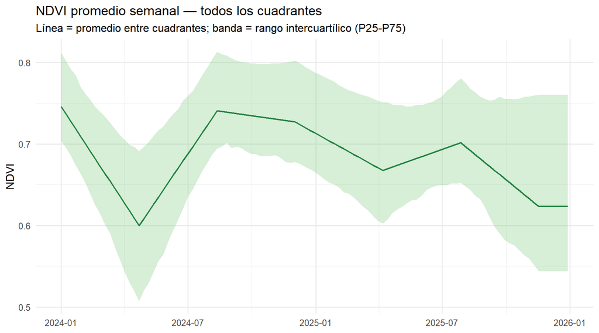

```r
ndvi_serie_global <- data_final %>%
  distinct(id_cuadrante, semana, ndvi_semanal) %>%
  group_by(semana) %>%
  summarise(
    ndvi_medio = mean(ndvi_semanal, na.rm = TRUE),
    ndvi_p25   = quantile(ndvi_semanal, 0.25, na.rm = TRUE),
    ndvi_p75   = quantile(ndvi_semanal, 0.75, na.rm = TRUE),
    .groups = "drop"
  )

ggplot(ndvi_serie_global, aes(x = semana)) +
  geom_ribbon(aes(ymin = ndvi_p25, ymax = ndvi_p75), fill = "#78c679", alpha = 0.3) +
  geom_line(aes(y = ndvi_medio), color = "#238443", linewidth = 0.8) +
  labs(
    title    = "NDVI promedio semanal — todos los cuadrantes",
    subtitle = "Línea = promedio entre cuadrantes; banda = rango intercuartílico (P25-P75)",
    x = NULL, y = "NDVI"
  ) +
  theme_minimal(base_size = 12)
```

## NDVI semanal — muestra de cuadrantes individuales

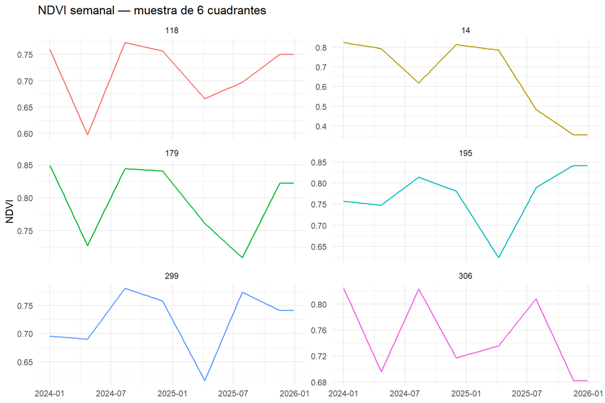

```r
set.seed(123)
muestra_series <- data_final %>%
  distinct(id_cuadrante) %>%
  slice_sample(n = 6) %>%
  pull(id_cuadrante)

data_final %>%
  distinct(id_cuadrante, semana, ndvi_semanal) %>%
  filter(id_cuadrante %in% muestra_series) %>%
  ggplot(aes(x = semana, y = ndvi_semanal, color = id_cuadrante)) +
  geom_line(linewidth = 0.6) +
  facet_wrap(~id_cuadrante, ncol = 2, scales = "free_y") +
  labs(
    title = "NDVI semanal — muestra de 6 cuadrantes",
    x = NULL, y = "NDVI"
  ) +
  theme_minimal(base_size = 11) +
  theme(legend.position = "none")
```

## Distribución del NDVI (todas las observaciones cuadrante-semana)

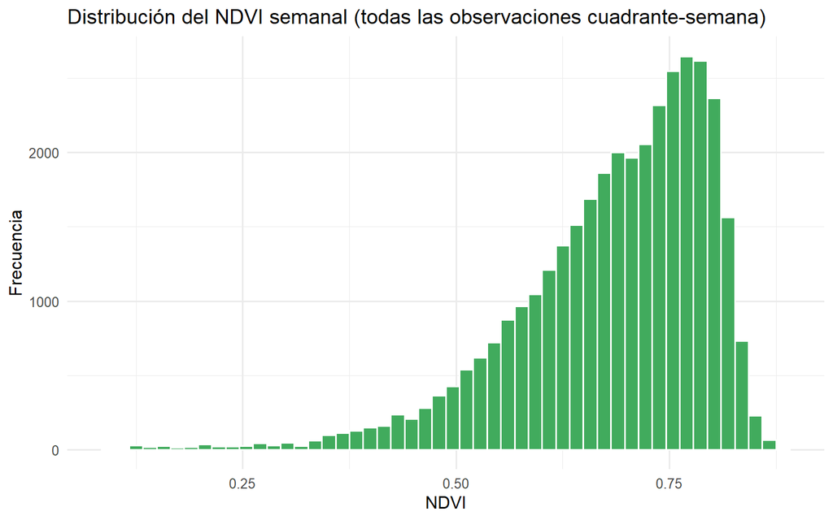

```r
data_final %>%
  distinct(id_cuadrante, semana, ndvi_semanal) %>%
  ggplot(aes(x = ndvi_semanal)) +
  geom_histogram(bins = 50, fill = "#41ab5d", color = "white") +
  labs(
    title = "Distribución del NDVI semanal (todas las observaciones cuadrante-semana)",
    x = "NDVI", y = "Frecuencia"
  ) +
  theme_minimal(base_size = 12)
```